# Decision Trees

INSOFE Lab Activity on Decision Trees

23 July 2017

# C5.0 Trees

**NOTE** Before starting this assignment please remember to clear your environment, you can do that by running the following code chunk

```r
rm(list = ls(all=T))
```

## Goal

- The goal of this activity is to predict wether a patient has liver disease or not based on various patient related attributes

## Agenda

- Get the data
- Data Pre-processing
- Build a model
- Predictions
- Communication

## Reading & Understanding the Data

### Read the Data

Make sure the dataset is located in your current working directory, or else you can change your working directory using the “setwd()” function.

```r
getwd()
```

```
## [1] "G:/DT assignment"
```

```r
setwd("G:/DT assignment")

read.csv("ilpd_data.csv",header = T,sep = ",")->df
df
```

```
##     age gender   TB   DB alk_phos alamine aspartate  TP albumin  A.G
## 1    62   Male 10.9  5.5      699      64       100 7.5     3.2 0.74
## 2    62   Male  7.3  4.1      490      60        68 7.0     3.3 0.89
## 3    58   Male  1.0  0.4      182      14        20 6.8     3.4 1.00
## 4    72   Male  3.9  2.0      195      27        59 7.3     2.4 0.40
## 5    46   Male  1.8  0.7      208      19        14 7.6     4.4 1.30
## 6    26 Female  0.9  0.2      154      16        12 7.0     3.5 1.00
## 7    29 Female  0.9  0.3      202      14        11 6.7     3.6 1.10
## 8    17   Male  0.9  0.3      202      22        19 7.4     4.1 1.20
## 9    55   Male  0.7  0.2      290      53        58 6.8     3.4 1.00
## 10   57   Male  0.6  0.1      210      51        59 5.9     2.7 0.80
## 11   72   Male  2.7  1.3      260      31        56 7.4     3.0 0.60
## 12   64   Male  0.9  0.3      310      61        58 7.0     3.4 0.90
## 13   74 Female  1.1  0.4      214      22        30 8.1     4.1 1.00
## 14   61   Male  0.7  0.2      145      53        41 5.8     2.7 0.87
```

[output cut: 1151 more lines]

```r
dim(df)
```

```
## [1] 582  11
```

### Understand the data

- Use the str(), summary(), head() and tail() functions to get the dimensions and types of attributes in the dataset
- The dataset has 582 observations and 11 variables
- **The variable descriptions are given below:**

1 - age : Age of the patient

2 - gender : Gender of the patient

3 - TB : Total Bilirubin content

4 - DB : Direct Bilirubin content

5 - alk_phos : Alkaline Phosphotase content

6 - alamine : Alamine Aminotransferase content

7 - aspartate : Aspartate Aminotransferase content

8 - TP : Total Protiens content

9 - albumin : Albumin content

10 - A/G : Ratio of Albumin and Globulin

11 - Disease : Whether the patient has liver disease or not

```r
str(df)
```

```
## 'data.frame':    582 obs. of  11 variables:
##  $ age      : int  62 62 58 72 46 26 29 17 55 57 ...
##  $ gender   : Factor w/ 2 levels "Female","Male": 2 2 2 2 2 1 1 2 2 2 ...
##  $ TB       : num  10.9 7.3 1 3.9 1.8 0.9 0.9 0.9 0.7 0.6 ...
##  $ DB       : num  5.5 4.1 0.4 2 0.7 0.2 0.3 0.3 0.2 0.1 ...
##  $ alk_phos : int  699 490 182 195 208 154 202 202 290 210 ...
##  $ alamine  : int  64 60 14 27 19 16 14 22 53 51 ...
##  $ aspartate: int  100 68 20 59 14 12 11 19 58 59 ...
##  $ TP       : num  7.5 7 6.8 7.3 7.6 7 6.7 7.4 6.8 5.9 ...
##  $ albumin  : num  3.2 3.3 3.4 2.4 4.4 3.5 3.6 4.1 3.4 2.7 ...
##  $ A.G      : num  0.74 0.89 1 0.4 1.3 1 1.1 1.2 1 0.8 ...
##  $ disease  : Factor w/ 2 levels "no","yes": 2 2 2 2 2 2 2 1 2 2 ...
```

```r
summary(df)
```

```
##       age           gender          TB               DB
##  Min.   : 4.00   Female:141   Min.   : 0.400   Min.   : 0.100
##  1st Qu.:33.00   Male  :441   1st Qu.: 0.800   1st Qu.: 0.200
##  Median :45.00                Median : 1.000   Median : 0.300
##  Mean   :44.71                Mean   : 3.303   Mean   : 1.488
##  3rd Qu.:57.75                3rd Qu.: 2.600   3rd Qu.: 1.300
##  Max.   :90.00                Max.   :75.000   Max.   :19.700
##
##     alk_phos         alamine          aspartate            TP
##  Min.   :  63.0   Min.   :  10.00   Min.   :  10.0   Min.   :2.700
##  1st Qu.: 175.2   1st Qu.:  23.00   1st Qu.:  25.0   1st Qu.:5.800
##  Median : 208.0   Median :  35.00   Median :  42.0   Median :6.600
##  Mean   : 290.8   Mean   :  80.82   Mean   : 110.1   Mean   :6.483
##  3rd Qu.: 298.0   3rd Qu.:  60.75   3rd Qu.:  87.0   3rd Qu.:7.200
##  Max.   :2110.0   Max.   :2000.00   Max.   :4929.0   Max.   :9.600
##
##     albumin           A.G         disease
##  Min.   :0.900   Min.   :0.3000   no :167
##  1st Qu.:2.600   1st Qu.:0.7000   yes:415
##  Median :3.100   Median :0.9400
##  Mean   :3.142   Mean   :0.9471
##  3rd Qu.:3.800   3rd Qu.:1.1000
##  Max.   :5.500   Max.   :2.8000
##                  NA's   :4
```

```r
head(df)
```

```
##   age gender   TB  DB alk_phos alamine aspartate  TP albumin  A.G disease
## 1  62   Male 10.9 5.5      699      64       100 7.5     3.2 0.74     yes
## 2  62   Male  7.3 4.1      490      60        68 7.0     3.3 0.89     yes
## 3  58   Male  1.0 0.4      182      14        20 6.8     3.4 1.00     yes
## 4  72   Male  3.9 2.0      195      27        59 7.3     2.4 0.40     yes
## 5  46   Male  1.8 0.7      208      19        14 7.6     4.4 1.30     yes
## 6  26 Female  0.9 0.2      154      16        12 7.0     3.5 1.00     yes
```

```r
tail(df)
```

```
##     age gender   TB  DB alk_phos alamine aspartate  TP albumin  A.G
## 577  32   Male 12.7 8.4      190      28        47 5.4     2.6 0.90
## 578  60   Male  0.5 0.1      500      20        34 5.9     1.6 0.37
## 579  40   Male  0.6 0.1       98      35        31 6.0     3.2 1.10
## 580  52   Male  0.8 0.2      245      48        49 6.4     3.2 1.00
## 581  31   Male  1.3 0.5      184      29        32 6.8     3.4 1.00
## 582  38   Male  1.0 0.3      216      21        24 7.3     4.4 1.50
##     disease
## 577     yes
## 578      no
## 579     yes
## 580     yes
## 581     yes
## 582      no
```

## Data Pre-processing

### Verify Data Integrity

- Verify if the dataset has missing values

```r
sum(is.na(df))
```

```
## [1] 4
```

```r
colSums(is.na(df))
```

```
##       age    gender        TB        DB  alk_phos   alamine aspartate
##         0         0         0         0         0         0         0
##        TP   albumin       A.G   disease
##         0         0         4         0
```

- Verify the data types assigned to the variables in the dataset

```r
str(df)
```

```
## 'data.frame':    582 obs. of  11 variables:
##  $ age      : int  62 62 58 72 46 26 29 17 55 57 ...
##  $ gender   : Factor w/ 2 levels "Female","Male": 2 2 2 2 2 1 1 2 2 2 ...
##  $ TB       : num  10.9 7.3 1 3.9 1.8 0.9 0.9 0.9 0.7 0.6 ...
##  $ DB       : num  5.5 4.1 0.4 2 0.7 0.2 0.3 0.3 0.2 0.1 ...
##  $ alk_phos : int  699 490 182 195 208 154 202 202 290 210 ...
##  $ alamine  : int  64 60 14 27 19 16 14 22 53 51 ...
##  $ aspartate: int  100 68 20 59 14 12 11 19 58 59 ...
##  $ TP       : num  7.5 7 6.8 7.3 7.6 7 6.7 7.4 6.8 5.9 ...
##  $ albumin  : num  3.2 3.3 3.4 2.4 4.4 3.5 3.6 4.1 3.4 2.7 ...
##  $ A.G      : num  0.74 0.89 1 0.4 1.3 1 1.1 1.2 1 0.8 ...
##  $ disease  : Factor w/ 2 levels "no","yes": 2 2 2 2 2 2 2 1 2 2 ...
```

```r
#lapply(df,table)
```

### Split the Data into train and test sets

- Use stratified sampling to split the data into train/test sets (70/30)
- Use the createDataPartition() function from the caret package to do stratified sampling

```r
library(caret)
set.seed(123)
createDataPartition(df$disease,p = 0.7,list = F)->dfsplit
df[dfsplit,]->trainlp
trainlp
```

```
##     age gender   TB   DB alk_phos alamine aspartate  TP albumin  A.G
## 2    62   Male  7.3  4.1      490      60        68 7.0     3.3 0.89
## 3    58   Male  1.0  0.4      182      14        20 6.8     3.4 1.00
## 5    46   Male  1.8  0.7      208      19        14 7.6     4.4 1.30
## 6    26 Female  0.9  0.2      154      16        12 7.0     3.5 1.00
## 7    29 Female  0.9  0.3      202      14        11 6.7     3.6 1.10
## 8    17   Male  0.9  0.3      202      22        19 7.4     4.1 1.20
## 9    55   Male  0.7  0.2      290      53        58 6.8     3.4 1.00
## 13   74 Female  1.1  0.4      214      22        30 8.1     4.1 1.00
## 16   38   Male  1.8  0.8      342     168       441 7.6     4.4 1.30
## 17   33   Male  1.6  0.5      165      15        23 7.3     3.5 0.92
## 18   40 Female  0.9  0.3      293     232       245 6.8     3.1 0.80
## 19   40 Female  0.9  0.3      293     232       245 6.8     3.1 0.80
## 20   51   Male  2.2  1.0      610      17        28 7.3     2.6 0.55
## 21   51   Male  2.9  1.3      482      22        34 7.0     2.4 0.50
```

[output cut: 803 more lines]

```r
dim(trainlp)
```

```
## [1] 408  11
```

```r
df[-dfsplit,]->testlp
dim(testlp)
```

```
## [1] 174  11
```

```r
colSums(is.na(trainlp))
```

```
##       age    gender        TB        DB  alk_phos   alamine aspartate
##         0         0         0         0         0         0         0
##        TP   albumin       A.G   disease
##         0         0         2         0
```

### Impute the missing values

- Impute missing values using knnImputation() function in both the train and test datasets

```r
library(DMwR)
knnImputation(data = trainlp,k = 5)->trainlp
colSums(is.na(trainlp))
```

```
##       age    gender        TB        DB  alk_phos   alamine aspartate
##         0         0         0         0         0         0         0
##        TP   albumin       A.G   disease
##         0         0         0         0
```

```r
knnImputation(data = testlp,k=5)->testlp
colSums(is.na(testlp))
```

```
##       age    gender        TB        DB  alk_phos   alamine aspartate
##         0         0         0         0         0         0         0
##        TP   albumin       A.G   disease
##         0         0         0         0
```

## Build a Decision Tree

### Model the tree

- Use Quinlan’s C5.0 decision tree algorithm implementation from the C50 package to build your decision tree

```r
library(C50)
C5.0(disease~.,data = trainlp)->dftree
dftree
```

```
##
## Call:
## C5.0.formula(formula = disease ~ ., data = trainlp)
##
## Classification Tree
## Number of samples: 408
## Number of predictors: 10
##
## Tree size: 1
##
## Non-standard options: attempt to group attributes
```

- Build a rules based tree

```r
C5.0(disease~.,data = trainlp,rules=T)->dfrules
dfrules
```

```
##
## Call:
## C5.0.formula(formula = disease ~ ., data = trainlp, rules = T)
##
## Rule-Based Model
## Number of samples: 408
## Number of predictors: 10
##
## Number of Rules: 0
##
## Non-standard options: attempt to group attributes
```

### Variable Importance in trees

- Find the importance of each variable in the dataset

```r
#C5imp(dftree,metric = "usage")
#C5imp(dftree,metric = "usage")
```

### Rules from trees

- Understand the summary of the returned c5.0 rules based on the decision tree model

```r
summary(dfrules)
```

```
##
## Call:
## C5.0.formula(formula = disease ~ ., data = trainlp, rules = T)
##
##
## C5.0 [Release 2.07 GPL Edition]      Tue Aug 01 18:29:45 2017
## -------------------------------
##
## Class specified by attribute `outcome'
##
## Read 408 cases (11 attributes) from undefined.data
##
## Rules:
##
## Default class: yes
##
##
## Evaluation on training data (408 cases):
##
##          Rules
##    ----------------
##      No      Errors
##
##       0  117(28.7%)   <<
##
##
##     (a)   (b)    <-classified as
##    ----  ----
##           117    (a): class no
##           291    (b): class yes
##
##
## Time: 0.0 secs
```

### Plotting the tree

- Call the plot function on the tree object to visualize the tree

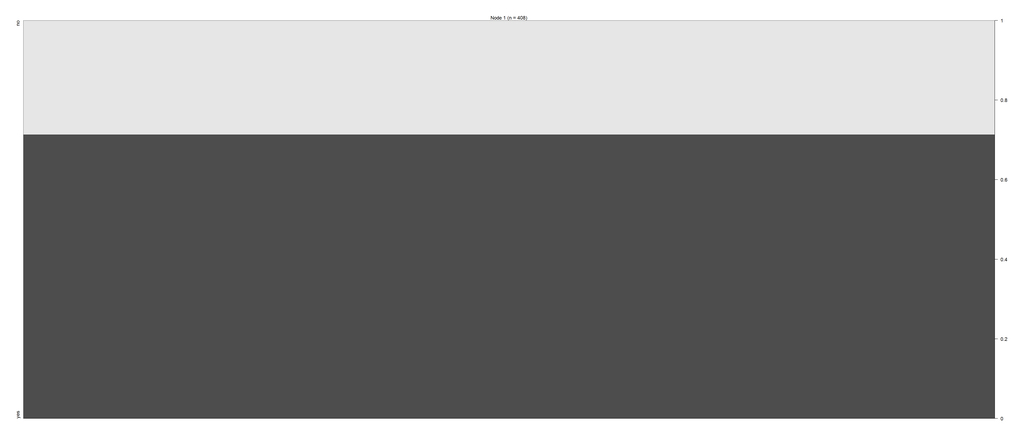

```r
plot(dftree)
```

## Evaluating the model

### Predictions on the test data

- Evaluate the decision tree using the standard error metrics on test data

```r
predict(dftree,testlp)->dfpredt

dfpredt
```

```
##   [1] yes yes yes yes yes yes yes yes yes yes yes yes yes yes yes yes yes
##  [18] yes yes yes yes yes yes yes yes yes yes yes yes yes yes yes yes yes
##  [35] yes yes yes yes yes yes yes yes yes yes yes yes yes yes yes yes yes
##  [52] yes yes yes yes yes yes yes yes yes yes yes yes yes yes yes yes yes
##  [69] yes yes yes yes yes yes yes yes yes yes yes yes yes yes yes yes yes
##  [86] yes yes yes yes yes yes yes yes yes yes yes yes yes yes yes yes yes
## [103] yes yes yes yes yes yes yes yes yes yes yes yes yes yes yes yes yes
## [120] yes yes yes yes yes yes yes yes yes yes yes yes yes yes yes yes yes
## [137] yes yes yes yes yes yes yes yes yes yes yes yes yes yes yes yes yes
## [154] yes yes yes yes yes yes yes yes yes yes yes yes yes yes yes yes yes
## [171] yes yes yes yes
## Levels: no yes
```

- Report error metrics for classification on test data

```r
library(caret)
#library(rattle)
confusionMatrix(dfpredt,testlp$disease)
```

```
## Confusion Matrix and Statistics
##
##           Reference
## Prediction  no yes
##        no    0   0
##        yes  50 124
##
##                Accuracy : 0.7126
##                  95% CI : (0.6393, 0.7786)
##     No Information Rate : 0.7126
##     P-Value [Acc > NIR] : 0.5381
##
##                   Kappa : 0
##  Mcnemar's Test P-Value : 4.219e-12
##
##             Sensitivity : 0.0000
##             Specificity : 1.0000
##          Pos Pred Value :    NaN
##          Neg Pred Value : 0.7126
##              Prevalence : 0.2874
##          Detection Rate : 0.0000
##    Detection Prevalence : 0.0000
##       Balanced Accuracy : 0.5000
##
##        'Positive' Class : no
##
```

# CART Trees

**NOTE** Before starting this assignment please remember to clear your environment, you can do that by running the following code chunk

```r
rm(list = ls(all=T))
```

- The classification and regression trees use gini index in place of the gain ratio (based on information gain) used by the ID3 based algorithms, such as c4.5 and c5.0

## Goal

- The goal of this activity is to predict the heating load of a residential building, if the building parameters are given
- Hence, in the future architects would be able to build more energy efficient buildings as they can optimize the building parameters to reduce the heating load

## Agenda

- Get the data
- Data Pre-processing
- Build a model
- Predictions
- Communication

## Reading & Understanding the Data

### Read the Data

- Make sure the dataset is located in your current working directory, or else you can change your working directory using the “setwd()” function.

```r
getwd()
```

```
## [1] "G:/DT assignment"
```

```r
setwd("G:/DT assignment")

read.csv("building_energy.csv",header = T,sep = ",")->be_data
be_data
```

```
##     relative_compactness surface_area wall_area roof_area overall_height
## 1                   0.98        514.5     294.0    110.25            7.0
## 2                   0.98        514.5     294.0    110.25            7.0
## 3                   0.98        514.5     294.0    110.25            7.0
## 4                   0.98        514.5     294.0    110.25            7.0
## 5                   0.90        563.5     318.5    122.50            7.0
## 6                   0.90        563.5     318.5    122.50            7.0
## 7                   0.90        563.5     318.5    122.50            7.0
## 8                   0.90        563.5     318.5    122.50            7.0
## 9                   0.86        588.0     294.0    147.00            7.0
## 10                  0.86        588.0     294.0    147.00            7.0
## 11                  0.86        588.0     294.0    147.00            7.0
## 12                  0.86        588.0     294.0    147.00            7.0
## 13                  0.82        612.5     318.5    147.00            7.0
## 14                  0.82        612.5     318.5    147.00            7.0
```

[output cut: 1523 more lines]

```r
dim(be_data)
```

```
## [1] 768   9
```

### Understand the data

- Use the str(), summary(), head() and tail() functions to get the dimensions and types of attributes in the dataset
- The dataset has 768 observations and 9 variables

```r
str(be_data)
```

```
## 'data.frame':    768 obs. of  9 variables:
##  $ relative_compactness     : num  0.98 0.98 0.98 0.98 0.9 0.9 0.9 0.9 0.86 0.86 ...
##  $ surface_area             : num  514 514 514 514 564 ...
##  $ wall_area                : num  294 294 294 294 318 ...
##  $ roof_area                : num  110 110 110 110 122 ...
##  $ overall_height           : num  7 7 7 7 7 7 7 7 7 7 ...
##  $ orientation              : int  2 3 4 5 2 3 4 5 2 3 ...
##  $ glazing_area             : num  0 0 0 0 0 0 0 0 0 0 ...
##  $ glazing_area_distribution: int  0 0 0 0 0 0 0 0 0 0 ...
##  $ heating_load             : num  15.6 15.6 15.6 15.6 20.8 ...
```

```r
summary(be_data)
```

```
##  relative_compactness  surface_area     wall_area       roof_area
##  Min.   :0.6200       Min.   :514.5   Min.   :245.0   Min.   :110.2
##  1st Qu.:0.6825       1st Qu.:606.4   1st Qu.:294.0   1st Qu.:140.9
##  Median :0.7500       Median :673.8   Median :318.5   Median :183.8
##  Mean   :0.7642       Mean   :671.7   Mean   :318.5   Mean   :176.6
##  3rd Qu.:0.8300       3rd Qu.:741.1   3rd Qu.:343.0   3rd Qu.:220.5
##  Max.   :0.9800       Max.   :808.5   Max.   :416.5   Max.   :220.5
##  overall_height  orientation    glazing_area    glazing_area_distribution
##  Min.   :3.50   Min.   :2.00   Min.   :0.0000   Min.   :0.000
##  1st Qu.:3.50   1st Qu.:2.75   1st Qu.:0.1000   1st Qu.:1.750
##  Median :5.25   Median :3.50   Median :0.2500   Median :3.000
##  Mean   :5.25   Mean   :3.50   Mean   :0.2344   Mean   :2.812
##  3rd Qu.:7.00   3rd Qu.:4.25   3rd Qu.:0.4000   3rd Qu.:4.000
##  Max.   :7.00   Max.   :5.00   Max.   :0.4000   Max.   :5.000
##   heating_load
##  Min.   : 6.01
##  1st Qu.:12.99
##  Median :18.95
##  Mean   :22.31
##  3rd Qu.:31.67
##  Max.   :43.10
```

```r
head(be_data)
```

```
##   relative_compactness surface_area wall_area roof_area overall_height
## 1                 0.98        514.5     294.0    110.25              7
## 2                 0.98        514.5     294.0    110.25              7
## 3                 0.98        514.5     294.0    110.25              7
## 4                 0.98        514.5     294.0    110.25              7
## 5                 0.90        563.5     318.5    122.50              7
## 6                 0.90        563.5     318.5    122.50              7
##   orientation glazing_area glazing_area_distribution heating_load
## 1           2            0                         0        15.55
## 2           3            0                         0        15.55
## 3           4            0                         0        15.55
## 4           5            0                         0        15.55
## 5           2            0                         0        20.84
## 6           3            0                         0        21.46
```

```r
tail(be_data)
```

```
##     relative_compactness surface_area wall_area roof_area overall_height
## 763                 0.64        784.0     343.0     220.5            3.5
## 764                 0.64        784.0     343.0     220.5            3.5
## 765                 0.62        808.5     367.5     220.5            3.5
## 766                 0.62        808.5     367.5     220.5            3.5
## 767                 0.62        808.5     367.5     220.5            3.5
## 768                 0.62        808.5     367.5     220.5            3.5
##     orientation glazing_area glazing_area_distribution heating_load
## 763           4          0.4                         5        18.16
## 764           5          0.4                         5        17.88
## 765           2          0.4                         5        16.54
## 766           3          0.4                         5        16.44
## 767           4          0.4                         5        16.48
## 768           5          0.4                         5        16.64
```

- The variable names are self explanatory, for further information visit http://www.sciencedirect.com/science/article/pii/S037877881200151X

## Data Pre-processing

### Verify Data Integrity

- Verify if the dataset has missing values

```r
sum(is.na(be_data))
```

```
## [1] 0
```

- Verify the data types assigned to the variables in the dataset

```r
# Enter answer here
str(be_data)
```

```
## 'data.frame':    768 obs. of  9 variables:
##  $ relative_compactness     : num  0.98 0.98 0.98 0.98 0.9 0.9 0.9 0.9 0.86 0.86 ...
##  $ surface_area             : num  514 514 514 514 564 ...
##  $ wall_area                : num  294 294 294 294 318 ...
##  $ roof_area                : num  110 110 110 110 122 ...
##  $ overall_height           : num  7 7 7 7 7 7 7 7 7 7 ...
##  $ orientation              : int  2 3 4 5 2 3 4 5 2 3 ...
##  $ glazing_area             : num  0 0 0 0 0 0 0 0 0 0 ...
##  $ glazing_area_distribution: int  0 0 0 0 0 0 0 0 0 0 ...
##  $ heating_load             : num  15.6 15.6 15.6 15.6 20.8 ...
```

### Split the Data

- Split the data into train/test sets (70/30)

```r
set.seed(123)
sample(1:nrow(be_data),0.7*nrow(be_data))->be_split
be_split
```

```
##   [1] 221 605 314 676 719  35 403 680 420 347 726 344 513 433  78 678 186
##  [18]  32 246 715 666 518 478 741 488 527 404 441 214 109 711 665 509 585
##  [35]  19 351 556 159 233 169 104 302 301 268 111 101 729 336 192 617  33
##  [52] 318 573  88 401 148  91 536 636 266 471  68 272 194 574 316 569 570
##  [69] 557 308 743 439 495   1 330 153 263 424 243  77 168 459 287 540  71
##  [86] 298 672 609 603 119  89 443 730 444 216 127 526  63 313 343 714 222
## [103] 326 635 321 591 606 762 706  97 616 198  40 621 472  93 359 622 381
## [120] 692 760 207 199 142 238 633  99  59 712 745 396 568 429 469 331 418
## [137] 520 497 618 277 196 257   7 115 682 145 149  48 693 454 524 307 239
## [154] 152  69 240 733 133 660 611 306 215 394 227 607 322 446 681 248 160
## [171] 377 110 515 445 397 367 768 766 517 669 494 184 416 156 348 281 155
## [188] 329 530 523 731 752 637 357 539 725 765 598  87 748 136 546 341 291
## [205] 228 496 205 162  96 659 269 141 121 375  27 388 195 226 452 505 582
## [222] 624 398 555  29 604 259 304 378 588 333 231 565 751 140 212 106 442
## [239]  82 426 289 350 640 538 164 379 209 506 504 685 134 625 764 138 273
```

[output cut: 17 more lines]

```r
be_data[be_split,]->be_train
be_train
```

```
##     relative_compactness surface_area wall_area roof_area overall_height
## 221                 0.71        710.5     269.5    220.50            3.5
## 605                 0.71        710.5     269.5    220.50            3.5
## 314                 0.74        686.0     245.0    220.50            3.5
## 676                 0.98        514.5     294.0    110.25            7.0
## 719                 0.62        808.5     367.5    220.50            3.5
## 35                  0.69        735.0     294.0    220.50            3.5
## 403                 0.79        637.0     343.0    147.00            7.0
## 680                 0.90        563.5     318.5    122.50            7.0
## 420                 0.69        735.0     294.0    220.50            3.5
## 347                 0.86        588.0     294.0    147.00            7.0
## 726                 0.90        563.5     318.5    122.50            7.0
## 344                 0.90        563.5     318.5    122.50            7.0
## 513                 0.69        735.0     294.0    220.50            3.5
## 433                 0.98        514.5     294.0    110.25            7.0
```

[output cut: 1061 more lines]

```r
dim(be_train)
```

```
## [1] 537   9
```

```r
be_data[-be_split,]->betest
dim(betest)
```

```
## [1] 231   9
```

```r
library(vegan)
```

## Build a Regression Tree

### Model the tree

- Use the rpart package to build a cart tree to predict the heating load

```r
library(rpart)

rpart(heating_load~.,data = be_train)->be_rpart
be_rpart
```

```
## n= 537
##
## node), split, n, deviance, yval
##       * denotes terminal node
##
##  1) root 537 54235.3800 22.27186
##    2) overall_height< 5.25 273  2013.1930 13.47297
##      4) glazing_area< 0.175 95   550.9881 11.19274 *
##      5) glazing_area>=0.175 178   704.6335 14.68994 *
##    3) overall_height>=5.25 264  9230.0290 31.37072
##      6) relative_compactness>=0.805 179  3404.9510 28.51860
##       12) glazing_area< 0.175 60   726.7152 24.37733 *
##       13) glazing_area>=0.175 119  1130.4020 30.60664 *
##      7) relative_compactness< 0.805 85  1302.6410 37.37694
##       14) glazing_area< 0.175 34   379.1571 33.71735 *
##       15) glazing_area>=0.175 51   164.5705 39.81667 *
```

```r
printcp(be_rpart)
```

```
##
## Regression tree:
## rpart(formula = heating_load ~ ., data = be_train)
##
## Variables actually used in tree construction:
## [1] glazing_area         overall_height       relative_compactness
##
## Root node error: 54235/537 = 101
##
## n= 537
##
##         CP nsplit rel error   xerror      xstd
## 1 0.792696      0  1.000000 1.007002 0.0381495
## 2 0.083385      1  0.207304 0.208413 0.0146844
## 3 0.028539      2  0.123919 0.124980 0.0096109
## 4 0.013993      3  0.095380 0.096733 0.0071921
## 5 0.013968      4  0.081387 0.090938 0.0069360
## 6 0.010000      5  0.067418 0.073302 0.0059459
```

### Tree Explicability

- Print the variable importance

```r
be_rpart$variable.importance
```

```
##      relative_compactness              surface_area
##                47514.5995                47514.5995
##            overall_height                 roof_area
##                42992.1627                42992.1627
##                 wall_area              glazing_area
##                17061.8176                 3064.3188
## glazing_area_distribution
##                  637.6964
```

- Plot the regression tree

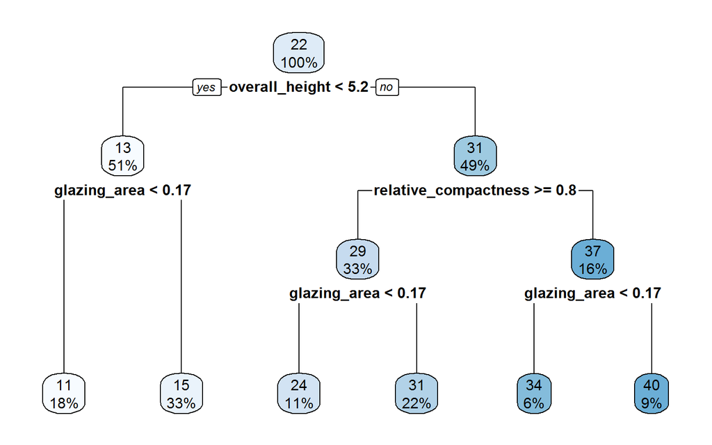

```r
library(rpart.plot)
rpart.plot(be_rpart)
```

## Evaluation on Test Data

- Report error metrics on the test data

```r
predict(be_rpart,betest)->pred
pred
```

```
##        2        3        6        9       12       13       17       18
## 24.37733 24.37733 24.37733 24.37733 24.37733 24.37733 33.71735 33.71735
##       21       23       25       31       34       41       42       43
## 33.71735 33.71735 11.19274 11.19274 11.19274 11.19274 11.19274 11.19274
##       45       46       50       52       53       56       57       60
## 11.19274 11.19274 24.37733 24.37733 24.37733 24.37733 24.37733 24.37733
##       61       65       72       74       76       84       86       92
## 24.37733 33.71735 33.71735 11.19274 11.19274 11.19274 11.19274 11.19274
##       94      100      102      103      105      107      116      117
## 11.19274 24.37733 24.37733 24.37733 24.37733 24.37733 33.71735 33.71735
##      118      122      124      128      129      130      135      139
## 33.71735 11.19274 11.19274 11.19274 11.19274 11.19274 11.19274 11.19274
##      146      150      151      154      158      161      165      170
## 24.37733 24.37733 24.37733 24.37733 24.37733 33.71735 33.71735 11.19274
##      171      172      174      176      181      182      183      185
## 11.19274 11.19274 11.19274 11.19274 11.19274 11.19274 11.19274 11.19274
##      188      189      200      201      202      206      208      210
## 11.19274 11.19274 24.37733 24.37733 24.37733 24.37733 24.37733 33.71735
##      217      218      220      232      235      236      237      242
## 11.19274 11.19274 11.19274 11.19274 11.19274 11.19274 11.19274 24.37733
##      244      247      249      250      252      253      255      260
## 24.37733 24.37733 24.37733 24.37733 24.37733 24.37733 24.37733 33.71735
##      264      267      270      274      275      278      280      282
## 33.71735 11.19274 11.19274 11.19274 11.19274 11.19274 11.19274 11.19274
##      283      285      288      292      294      299      300      303
## 11.19274 11.19274 11.19274 30.60664 30.60664 30.60664 30.60664 30.60664
##      305      309      310      312      315      317      319      324
## 39.81667 39.81667 39.81667 39.81667 14.68994 14.68994 14.68994 14.68994
##      325      328      337      338      339      345      346      352
## 14.68994 14.68994 30.60664 30.60664 30.60664 30.60664 30.60664 30.60664
##      353      355      360      361      362      369      373      374
## 39.81667 39.81667 39.81667 14.68994 14.68994 14.68994 14.68994 14.68994
##      376      382      391      392      393      395      405      406
## 14.68994 14.68994 30.60664 30.60664 30.60664 30.60664 39.81667 39.81667
##      409      413      414      417      423      425      430      432
## 14.68994 14.68994 14.68994 14.68994 14.68994 14.68994 14.68994 14.68994
##      437      440      450      453      455      456      457      458
## 30.60664 30.60664 39.81667 39.81667 39.81667 39.81667 14.68994 14.68994
##      461      465      467      468      474      475      476      481
## 14.68994 14.68994 14.68994 14.68994 14.68994 14.68994 14.68994 30.60664
##      482      484      485      487      489      491      499      500
## 30.60664 30.60664 30.60664 30.60664 30.60664 30.60664 39.81667 39.81667
##      501      502      503      507      510      512      525      528
## 39.81667 39.81667 39.81667 14.68994 14.68994 14.68994 14.68994 14.68994
##      529      534      537      542      548      549      553      558
## 30.60664 30.60664 30.60664 30.60664 39.81667 39.81667 14.68994 14.68994
##      564      566      576      578      594      596      600      602
## 14.68994 14.68994 14.68994 30.60664 39.81667 39.81667 39.81667 14.68994
##      608      613      615      620      623      627      628      632
## 14.68994 14.68994 14.68994 14.68994 14.68994 30.60664 30.60664 30.60664
##      634      638      642      643      646      649      657      664
## 30.60664 30.60664 39.81667 39.81667 39.81667 14.68994 14.68994 14.68994
##      667      668      670      671      674      677      679      683
## 14.68994 14.68994 14.68994 14.68994 30.60664 30.60664 30.60664 30.60664
##      686      687      697      698      699      704      713      716
## 30.60664 30.60664 14.68994 14.68994 14.68994 14.68994 14.68994 14.68994
##      735      737      738      744      746      749      755
## 30.60664 39.81667 39.81667 39.81667 14.68994 14.68994 14.68994
```

```r
library(DMwR)
regr.eval(betest$heating_load,pred)
```

```
##       mae       mse      rmse      mape
## 2.0686987 7.2917648 2.7003268 0.1085194
```